# Drumming Styles: A Distributional Feature Analysis

Maximilian Van Zandt | Department of Statistics, University of Virginia

2025-12-01

## Introduction

**Question**: Can we quantify drumming style?

**Problem**: Quantify latent dimensions of drumming performance style using interpretable statistical methods.

**Data**: Groove MIDI Dataset (Gillick et al., 2019)

- 446,312 hits
- 10 drummers
- 1,150 recordings

**Hypotheses**:

H₁: Variation in drumming style decomposes into independent latent dimensions spanning kit utilization (pitch), dynamics, and temporal structure.

H₂: Individual drummers exhibit distinct, quantifiable distributions in velocity, timing, and pitch.

**Goal**: Find interpretable dimensions of playing style.

**Methods**

*Distributional Analysis*  
Kernel Density Estimation with Gaussian kernels, bandwidth *h* = 1.06*σn*<sup>−1/5</sup> (Silverman).

*Temporal Extension*  
3-state Hidden Markov Models on rock recordings, Baum-Welch EM estimation, Gaussian emissions.

## Results: Three Independent Dimensions

**Top Loadings**

| PC | Feature | λ |
| --- | --- | --- |
| **PC1** | Open Hi-Hat | .30 |
| *Kit* | Ride Cymbal | .30 |
| (27.6%) | Hi-Mid Tom | .30 |
|  | Snare | .27 |
| **PC2** | Mean Velocity | .32 |
| *Power* | Mean IOI | .31 |
| (24.8%) | Velocity CV | −.29 |
| **PC3** | Open HH (alt) | .39 |
| *Timing* | Closed HH | .32 |
| (11.5%) | IOI CV | .25 |

PC1 and PC2 dominate but PC3 adds meaningful timing information.

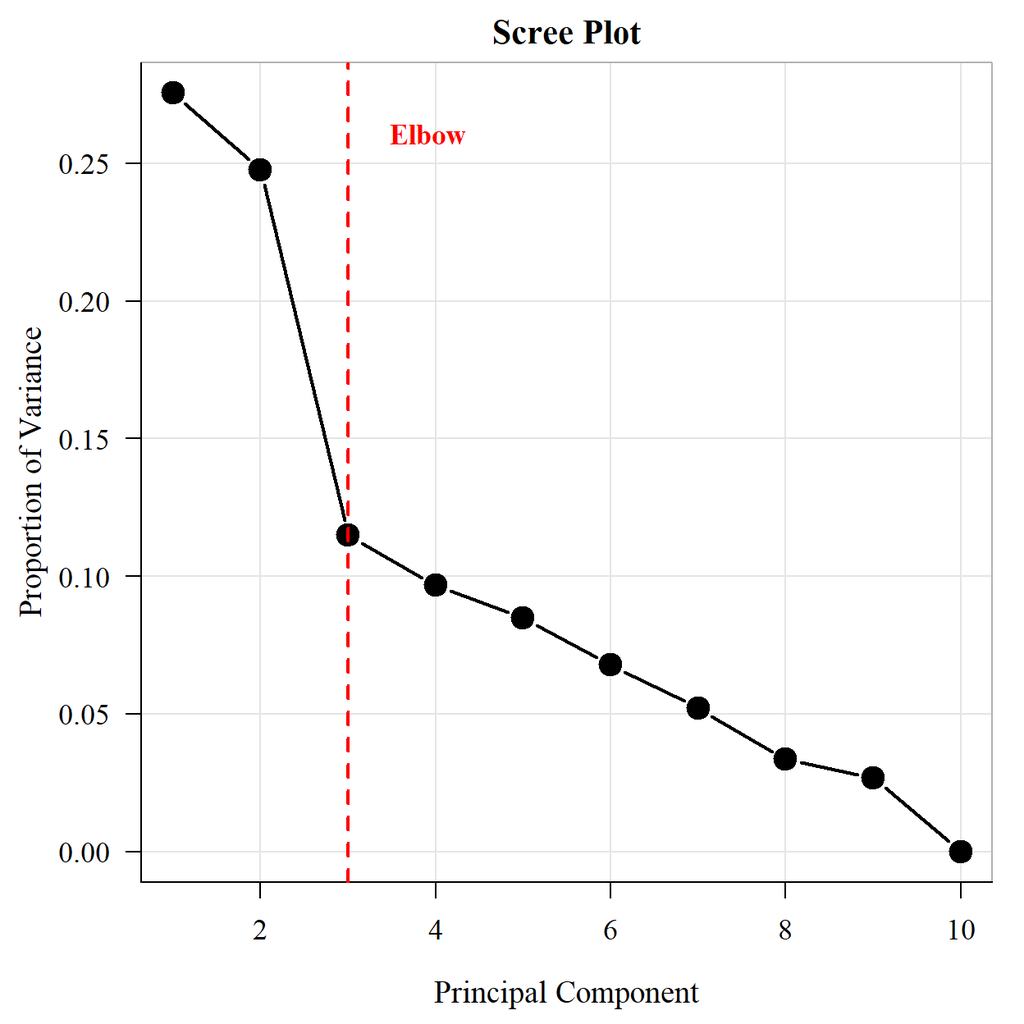

**First 3 PCs: 63.8% variance**

**Key Insight**: Style isn’t one thing; kit choice and dynamics matter equally.

**Validation**: PC2 correlates with mean velocity.

(*r* = .89)

## Results: Drummers Have Distinct Signatures

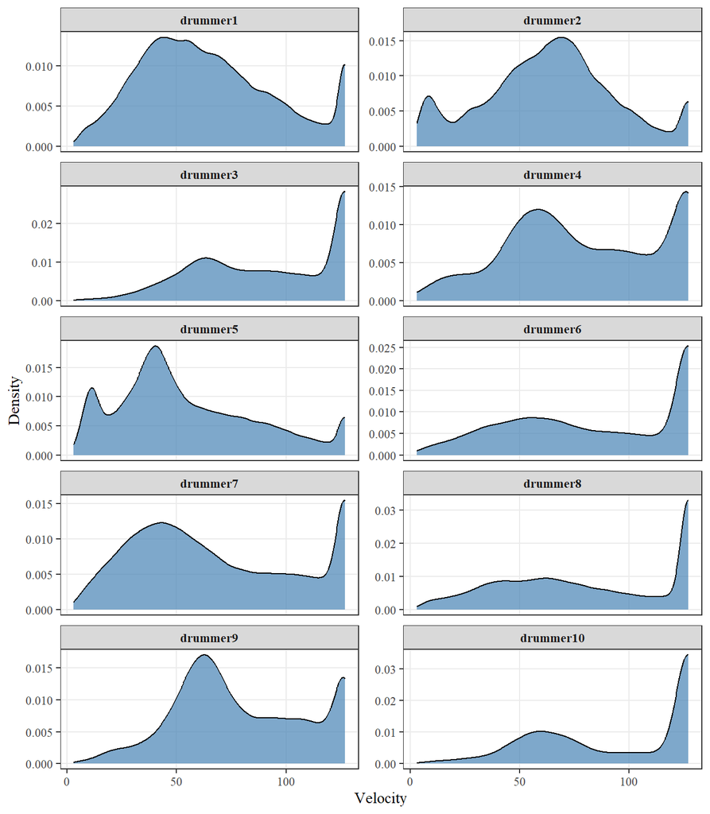

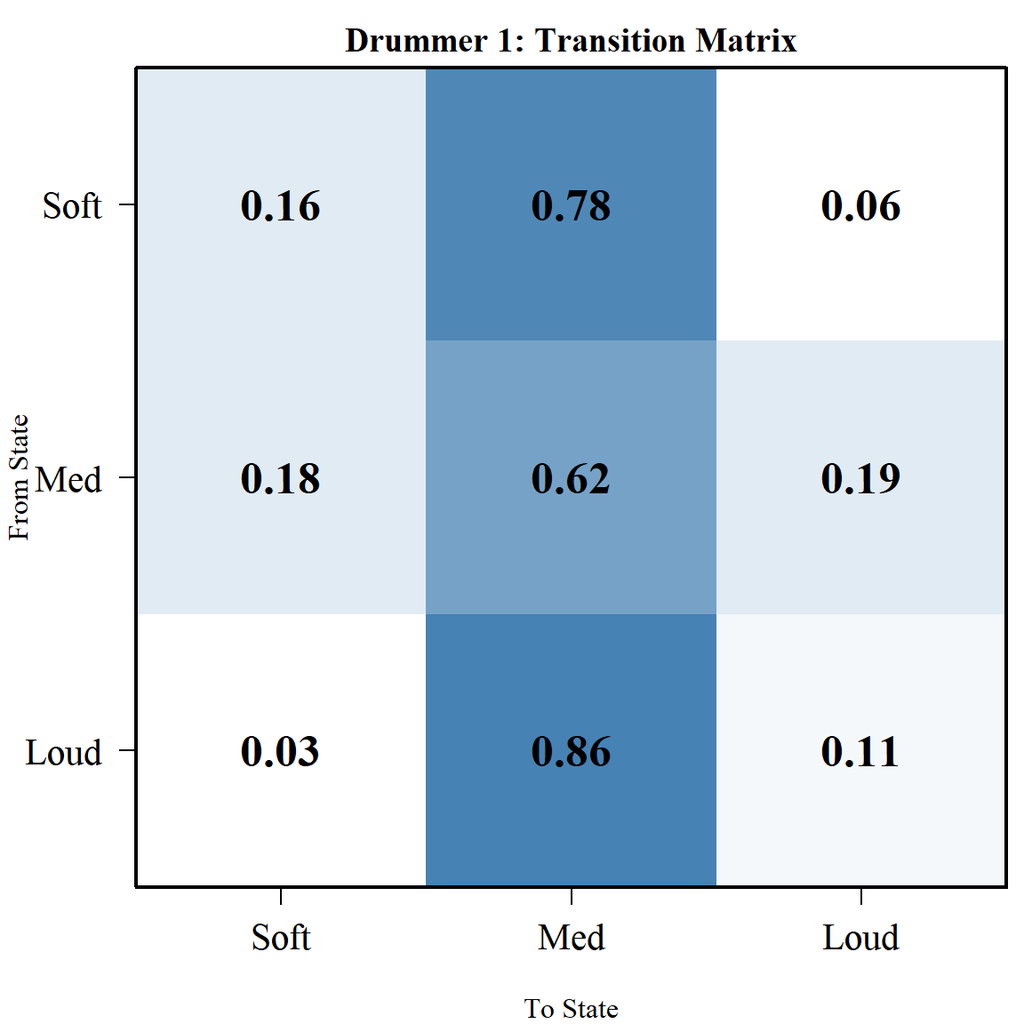

## Conclusion

**Why it matters:** Quantifiable, interpretable methods work. Can be applied to music pedagogy, style classification, and generative models.

**Next:** Test across genres, expand to larger dataset with audio features. Expand HMM analysis to more recordings, potentially exploring other state-space models for temporal transitions.